# Analysis of Wine Quality based on Chemical Ingredients

#### Correlations between output feature Quality and other features

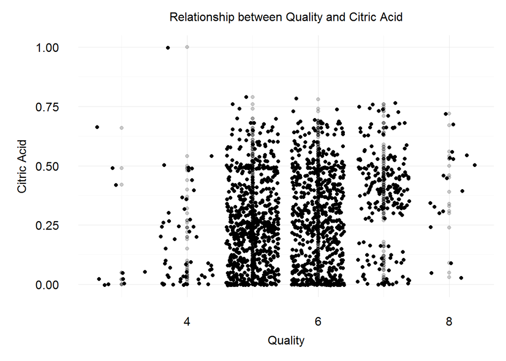

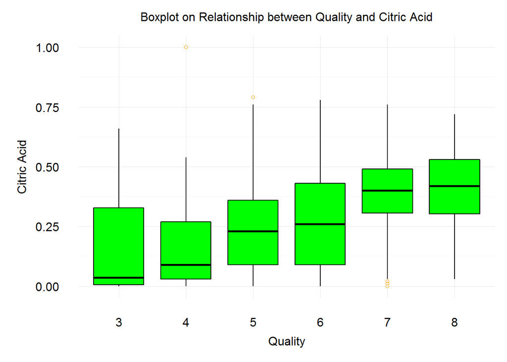

```
##
##  Spearman's rank correlation rho
##
## data:  citric.acid and quality
## S = 535920000, p-value < 2.2e-16
## alternative hypothesis: true rho is not equal to 0
## sample estimates:
##       rho
## 0.2134809
```

A positive correlation of 0.213 exists between *Citric Acid* and *Quality* of wines. That correlation seems to be rather low. As stated already, *Citric Acid* is adding freshness and flavor to the wine which should increase its *Quality*. Apart from only looking into the correlation we further look into the above plots.

The scatterplot shows that none of the wines with *Quality* 8 has zero *Citric Acid*, where all others do. On that note, we also look into  
high *Citric Acid* values and see that the distributed amongst all different groups of *Quality*, altough values for *Quality* 3 are remarkable lower. Never the less, the boxplot changes the picture a bit and provides important information about the distribution of *Citric Acid* values in the different *Quality* groups. It clearly outlines that the *Quality* of wines increases with the amount of *Citric Acid*.

The below basic statistics of *Citric Acid* grouped by Quality value is confirming above statements about minimal values as well about the distribution of data:

```r
summary(subset(wine_data_raw, quality ==3)$citric.acid)
```

```
##    Min. 1st Qu.  Median    Mean 3rd Qu.    Max.
##  0.0000  0.0050  0.0350  0.1710  0.3275  0.6600
```

```r
summary(subset(wine_data_raw, quality ==4)$citric.acid)
```

```
##    Min. 1st Qu.  Median    Mean 3rd Qu.    Max.
##  0.0000  0.0300  0.0900  0.1742  0.2700  1.0000
```

```r
summary(subset(wine_data_raw, quality ==5)$citric.acid)
```

```
##    Min. 1st Qu.  Median    Mean 3rd Qu.    Max.
##  0.0000  0.0900  0.2300  0.2437  0.3600  0.7900
```

```r
summary(subset(wine_data_raw, quality ==6)$citric.acid)
```

```
##    Min. 1st Qu.  Median    Mean 3rd Qu.    Max.
##  0.0000  0.0900  0.2600  0.2738  0.4300  0.7800
```

```r
summary(subset(wine_data_raw, quality ==7)$citric.acid)
```

```
##    Min. 1st Qu.  Median    Mean 3rd Qu.    Max.
##  0.0000  0.3050  0.4000  0.3752  0.4900  0.7600
```

```r
summary(subset(wine_data_raw, quality ==8)$citric.acid)
```

```
##    Min. 1st Qu.  Median    Mean 3rd Qu.    Max.
##  0.0300  0.3025  0.4200  0.3911  0.5300  0.7200
```

In the above statistic information Especially by taking a look at mean and median we recognize that the in general the numbers for *Citric Acid* go up as the *Quality* increases.

Finally, we can state that the correlation between *Citric Acid* and *Quality* is rather low, but it can be detected when looking at the plots and basic statistics. Also, best *Quality* wines all have a *Citric Acid* value higher 0.

Next, we take a look at the relationship between *Total Sulphur Dioxide* and *Quality*.

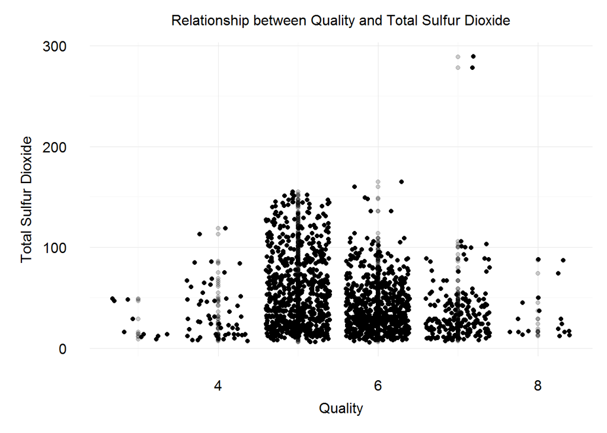

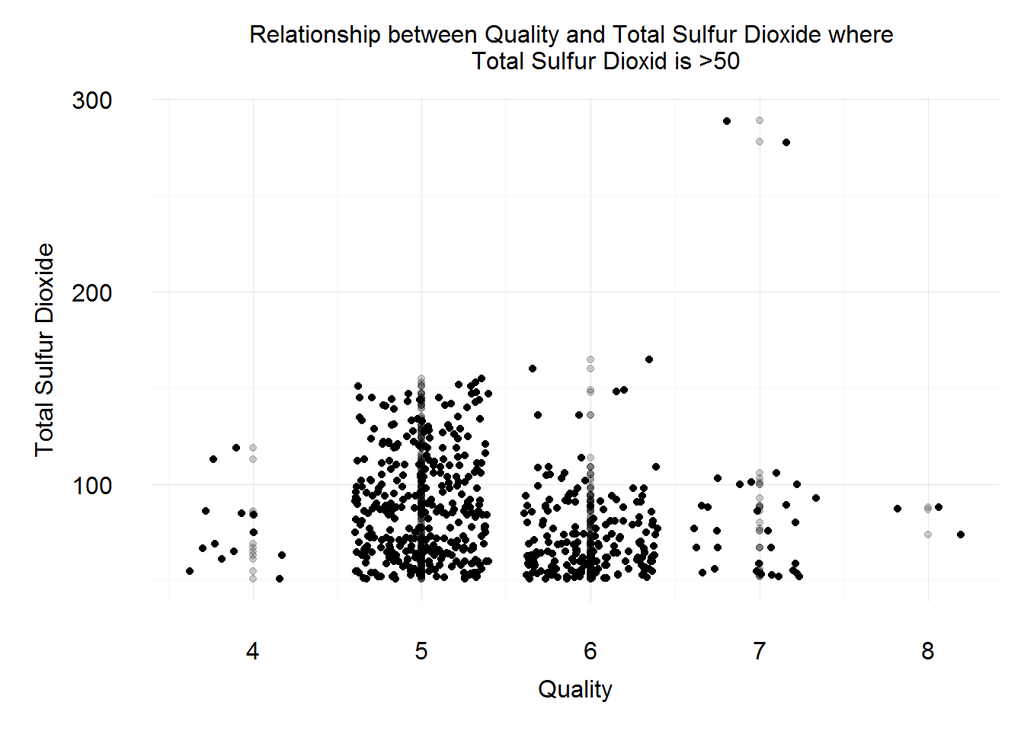

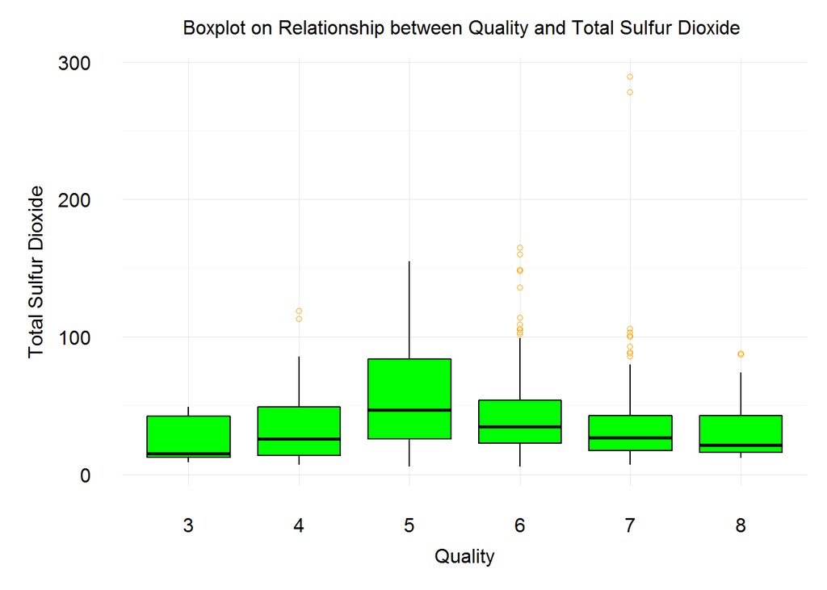

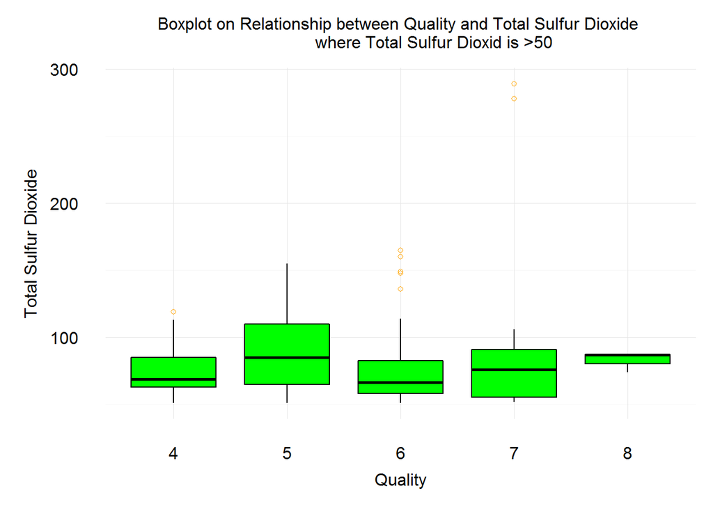

```
##
##  Spearman's rank correlation rho
##
## data:  total.sulfur.dioxide and quality
## S = 815440000, p-value = 2.046e-15
## alternative hypothesis: true rho is not equal to 0
## sample estimates:
##        rho
## -0.1967351
```

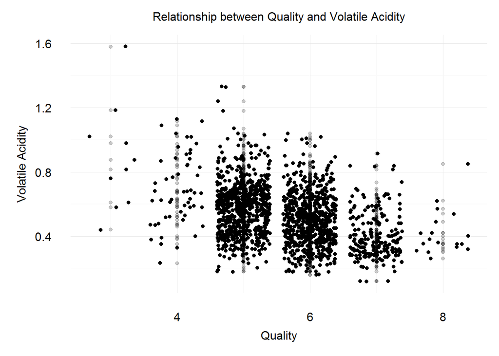

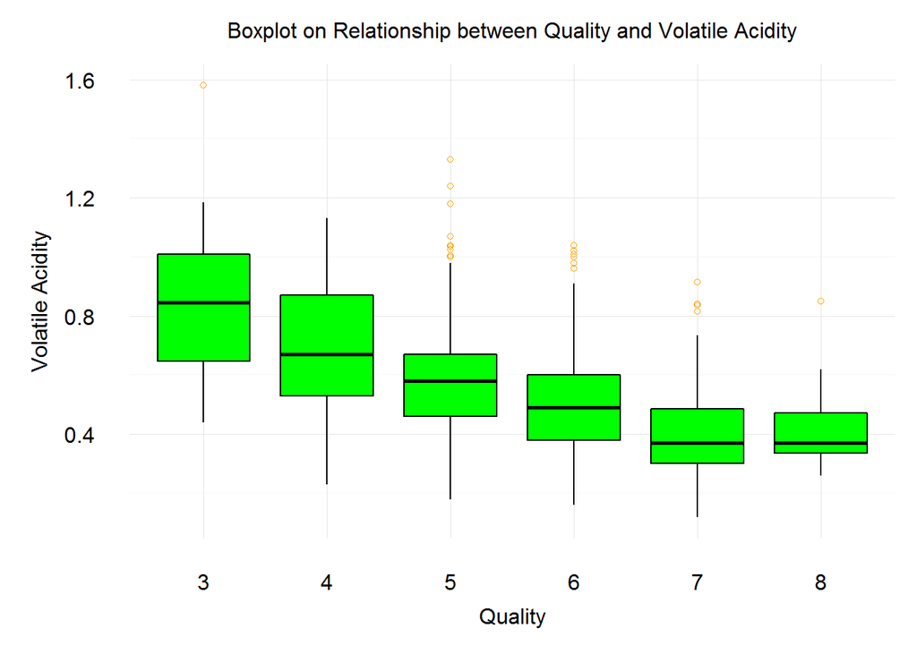

```
##
##  Spearman's rank correlation rho
##
## data:  volatile.acidity and quality
## S = 940750000, p-value < 2.2e-16
## alternative hypothesis: true rho is not equal to 0
## sample estimates:
##        rho
## -0.3806465
```

A negative correlation of -0.381 exists between *Volatile Acidity* and *Quality* of wines. That is what we can also recognize when we look at the plots above.

In the scatterplot we see that there is a quite low number of wines with *Quality* 3 and all of them do have a value for *Volatile Acidity* which is above 0.4. On the other side of the *Quality* scale we can see that there are a few more wines with *Quality* 8 than 3. And most of the wine with *Qaulity* have a *Volatile Acidity* value of below 0.4. We can also recognize some *Volatile Acidity* value outliers on most of the different *Quality* value data. For example data of *Quality* 3 shows an extreme outlier at about 1.6, also *Quality* 8 data shows an outlier at about 0.85. The boxplot provides even better visibility of the correlation between the two values and clearly shows the outliers.

Let’s take a look at the basics statistics of *Volatile Acidity* grouped by Quality value:

```r
summary(subset(wine_data_raw, quality ==3)$volatile.acidity)
```

```
##    Min. 1st Qu.  Median    Mean 3rd Qu.    Max.
##  0.4400  0.6475  0.8450  0.8845  1.0100  1.5800
```

```r
summary(subset(wine_data_raw, quality ==4)$volatile.acidity)
```

```
##    Min. 1st Qu.  Median    Mean 3rd Qu.    Max.
##   0.230   0.530   0.670   0.694   0.870   1.130
```

```r
summary(subset(wine_data_raw, quality ==5)$volatile.acidity)
```

```
##    Min. 1st Qu.  Median    Mean 3rd Qu.    Max.
##   0.180   0.460   0.580   0.577   0.670   1.330
```

```r
summary(subset(wine_data_raw, quality ==6)$volatile.acidity)
```

```
##    Min. 1st Qu.  Median    Mean 3rd Qu.    Max.
##  0.1600  0.3800  0.4900  0.4975  0.6000  1.0400
```

```r
summary(subset(wine_data_raw, quality ==7)$volatile.acidity)
```

```
##    Min. 1st Qu.  Median    Mean 3rd Qu.    Max.
##  0.1200  0.3000  0.3700  0.4039  0.4850  0.9150
```

```r
summary(subset(wine_data_raw, quality ==8)$volatile.acidity)
```

```
##    Min. 1st Qu.  Median    Mean 3rd Qu.    Max.
##  0.2600  0.3350  0.3700  0.4233  0.4725  0.8500
```

In the above statistic information we can see the in general the numbers for *Volatile Acidity* go down as the *Quality* increases. Especially by taking a look at the median - robust against outliers - we see much lower numbers for *Quality* 7 and 8, compared to the rest of the data.

So, according to the correlation of *Volatile Acidity* and *Quality*, as well as after taking a look at the scatterplot, boxplot and the basic statistics of the data, the statement regarding the unpleasant, vinegar taste of wine in case of too high *Volatile Acidity* values seems to hold true.

Next, we take a look at the relationship between *Alcohol* and *Quality*.

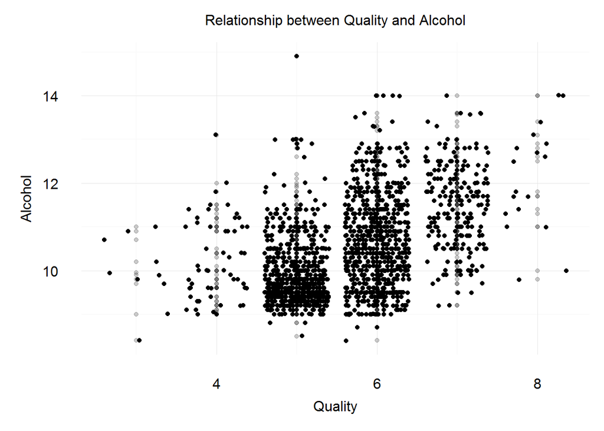

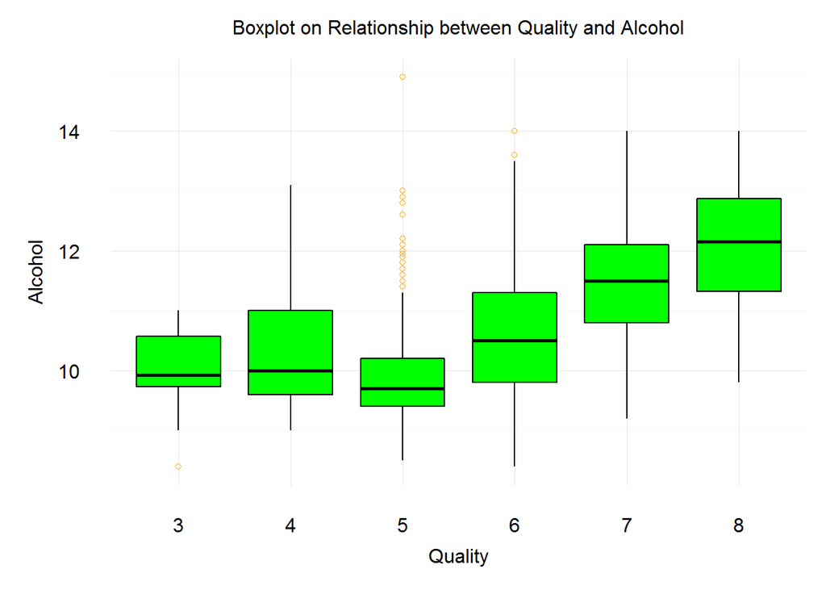

```
##
##  Spearman's rank correlation rho
##
## data:  alcohol and quality
## S = 355320000, p-value < 2.2e-16
## alternative hypothesis: true rho is not equal to 0
## sample estimates:
##       rho
## 0.4785317
```

There is a positive correlation of 0.479 between *Alcohol* and *Quality*.

Looking at the above boxplot we can see that wine with *quality* 3, 4 and 5 the alcohol Vol.% is rather low (10 and below). Looking at data for *quality* 5 we can see that there are a lot of outliers on the higher side.

Also the scatterplot shows some interesting data. For example there are wines with *quality* 8 which do have an quite low *alcohol* value of about 10 Vol.%. On the other side for a quite low quality wine with *quality* 4 we can see an *alcohol* value of more than 13 Vol.%.

Let’s take a look at the basics statistics of *Alcohol* grouped by Quality value:

```r
summary(subset(wine_data_raw, quality ==3)$alcohol)
```

```
##    Min. 1st Qu.  Median    Mean 3rd Qu.    Max.
##   8.400   9.725   9.925   9.955  10.580  11.000
```

```r
summary(subset(wine_data_raw, quality ==4)$alcohol)
```

```
##    Min. 1st Qu.  Median    Mean 3rd Qu.    Max.
##    9.00    9.60   10.00   10.27   11.00   13.10
```

```r
summary(subset(wine_data_raw, quality ==5)$alcohol)
```

```
##    Min. 1st Qu.  Median    Mean 3rd Qu.    Max.
##     8.5     9.4     9.7     9.9    10.2    14.9
```

```r
summary(subset(wine_data_raw, quality ==6)$alcohol)
```

```
##    Min. 1st Qu.  Median    Mean 3rd Qu.    Max.
##    8.40    9.80   10.50   10.63   11.30   14.00
```

```r
summary(subset(wine_data_raw, quality ==7)$alcohol)
```

```
##    Min. 1st Qu.  Median    Mean 3rd Qu.    Max.
##    9.20   10.80   11.50   11.47   12.10   14.00
```

```r
summary(subset(wine_data_raw, quality ==8)$alcohol)
```

```
##    Min. 1st Qu.  Median    Mean 3rd Qu.    Max.
##    9.80   11.32   12.15   12.09   12.88   14.00
```

In general we can see the positive correlation reflected in the above basic statistical information grouped by *Quality*. Surprisingly, the values for *Quality* 5 are the lowest in most numbers, although in that *Quality* group we can also see the highest values of the complete dataset.

In the following, 6 histograms on *Quality* are provided to illustrate how the *quality* of wine is distributed amongst the different *alcohol* proportion ranges. For orientation purposes, the median and mean of the complete dataset are provided in each of the histograms of the different subsets. The lowest value is 8.40 Vol.%, so the lower boundry for the first histogram is 8 Vol.%. Also, the highest value for *alcohol* is 14.90 Vol.%, so the higher boundry for the last histogram subset is 15 Vol.%.

The histograms below show 4 different vertical lines which provide the following information:

- BLACK: Mean of the feature *quality* for the overall dataset
- BLACK DASHED: Median of the feature *quality* for the overall dataset
- RED: Mean of the feature *quality* for the specific subset (specific alcohol range) of the dataset
- RED DASHED: Median of the feature *quality* for the specific subset (specific alcohol range) of the dataset

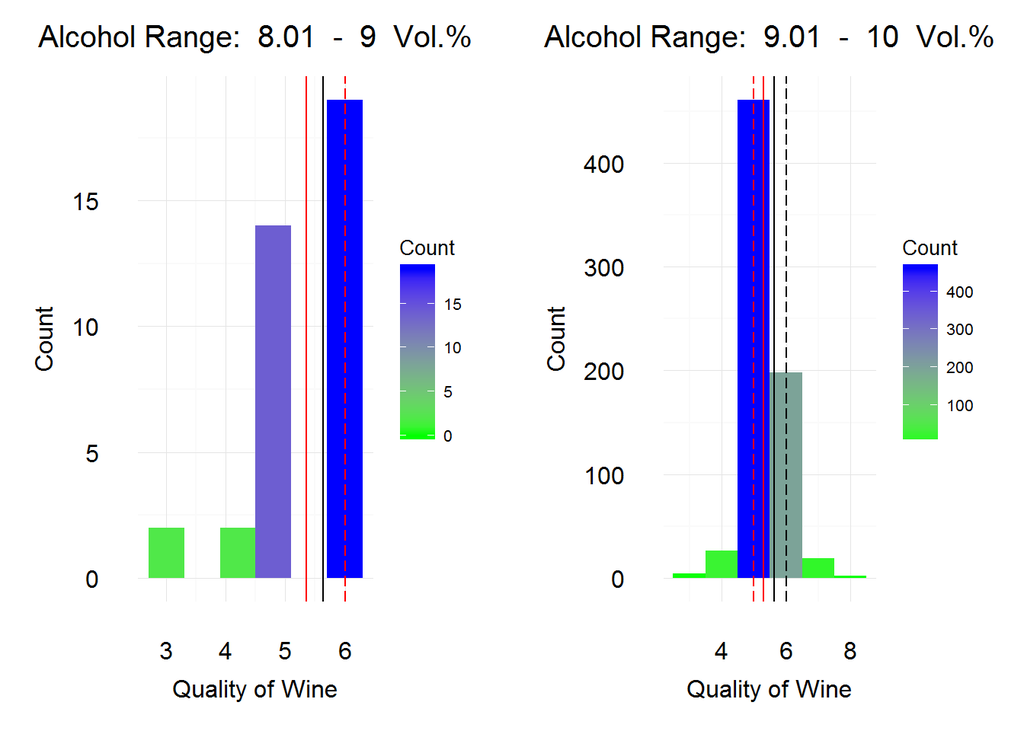

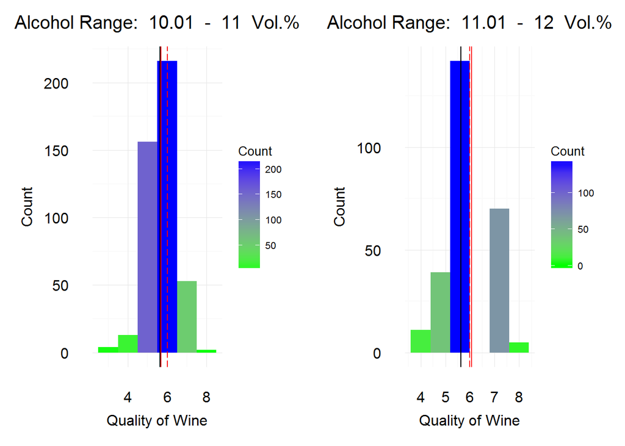

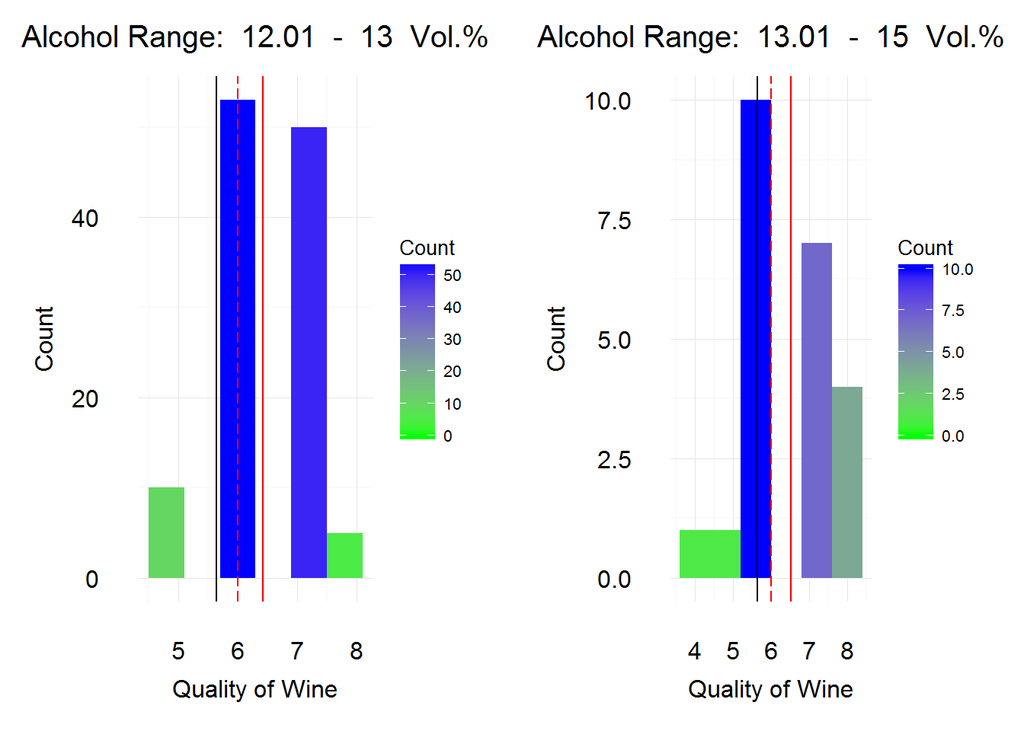

Altough the histograms on specific alcohol ranges show similar result, there are quite some differences when taking a closer look. Histogram 1 (subset of data between 8.01 and 9 Vol.% alcohol) shows a median of 6 for the specific alcohol range, which is identical to the overall median. However, one can see that the range of quality in Histogram 1 is between 3 and 6 and thereby one the lower quality side of the scale. Also, the mean of this subset is below the mean of the complete dataset. This subset represents a rather small part of the overall dataset with less than 2.5 % of all records.

Histogram 2 (subset of data between 9.01 and 10 Vol.% alcohol) shows a range between 3 and 8. The median and mean of the specific subset are below the of those of the complete dataset. Unique for that range is the median of 5, whereas all other subsets do show a median of 6. This subset consists of about 650 records and theirfor represents about 40 % of the data.

Histogram 3 (subset of data between 10.01 and 11 Vol.% alcohol) is based on another big subset of the complete dataset with about 28 % of all records. In the historgram one can see that the mean of the subset is above the mean of the dataset. We can also see that quality 5, which is below the mean and medium of both, the subset and the complete dataset, occures quite often in more than 150 cases.

The subset which is the base for Histogram 4 (subset of data between 11.01 and 12 Vol.% alcohol) consists of about 17 % of all records. Both, median is at 6 and mean is slightly higher than 6. There is also a quite high occurence of wines with quality 7 and some with quality 8.

Histogram 5 (subset of data between 12.01 and 13 Vol.% alcohol) and 6 (subset of data between 13.01 and 15 Vol.% alcohol) both visualize that the mean of two dataset are at about 6.5. In both datasets we can see a quite high proportion of wines with quality 6, 7, or even 8. However, total numbers are lower for those subsets, and thereby the overall impact to the complete dataset is rather small. Nevertheless, one can see a high proportion of wines with quality 8 especially in Histogram 6.

What can be recognized by analyzing above histograms is, that the quality of wines increases as the Vol.% alcohol in the wine increases. Despite we can see that a median of 6 is true for almost all the datasets (except dataset of Histogram 2), we recognize that the mean of the different subsets is increasing along with the Vol.% alcohol and thereby supports our first statement, the assumption that *quality* and *alcohol* correlate positivley. Further, we can see that there is no wine of quality 3 in the subset with the highest alcohol Vol.%.

Considering the different above analyses we can say that indeed the amount of *Alcohol* in the wine tends to impact the *Quality* of wines. The correlation of *Alcohol* Acidity_ and *Quality*, as well as the scatterplot, boxplot and the basic statistics of the data, support that finding.

# Bivariate Analysis

### Talk about some of the relationships you observed in this part of the investigation. How did the feature(s) of interest vary with other features in the dataset?

*pH* value showed a high correlation with *Fixed Acidity* and *Citric Acid*. However, that seemed to be quite obvious as *pH* value is a value describing whether and to what degree something (in our case wine) is basic or acid. However, the correlation between *pH* and *Quality* is very low and thereby that features is not impacting the *Quality* of a wine.

The correlation between Citric Acid and Quality is rather low, but it can be detected when looking at the plots and basic statistics. Also, best Quality wines all have a Citric Acid value higher 0.

The correlation between Citric Acid and Quality is rather low, but it can be detected when looking at the plots and basic statistics. Also, best Quality wines all have a Citric Acid value higher 0.

According to the above analysis, the statement regarding the unpleasant, vinegar taste of wine in case of too high Volatile Acidity values seems to hold true.

The investigations above showed that *Alcohol* has a quite strong correlation with *Density*. And most importantly shows a positive correlation of 0.479 with *Quality* of the wine. In the above analysis we were able to find evidence supporting the positive correlation *Alcohol*. The amount of Alcohol in the winetends to impact the Quality of wines.

### Did you observe any interesting relationships between the other features (not the main feature(s) of interest)?

Indeed there are a lot of interesting relationships and correlations which are not related to the main features of interest. Further information can be found in the above section already, where I also outlined some of the significant relationships.

### What was the strongest relationship you found?

Negative correlation between *Fixed Acidity* and *pH*.

# Multivariate Plots Section

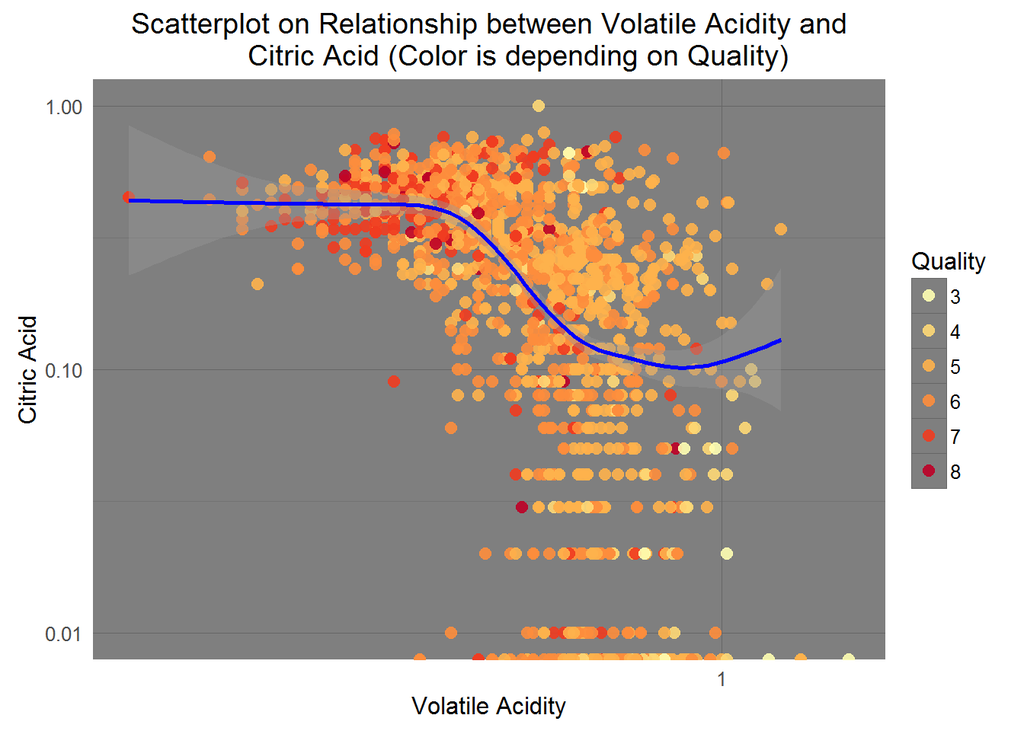

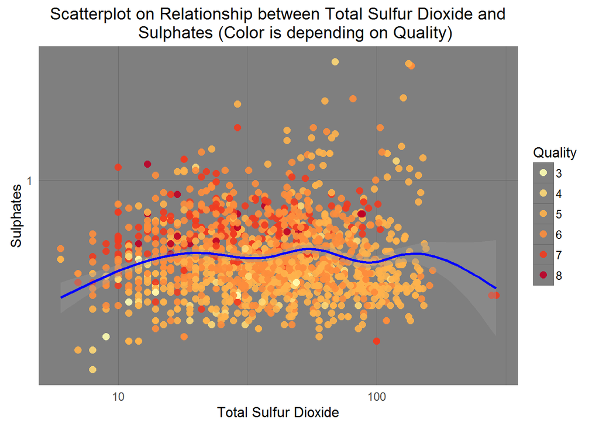

[figure not shown]

In the below line charts we can see that there is a low correlation between *Alcohol* and *pH*. Therefore, we look independently at values of Quality ranges 3-5 and 6-8.

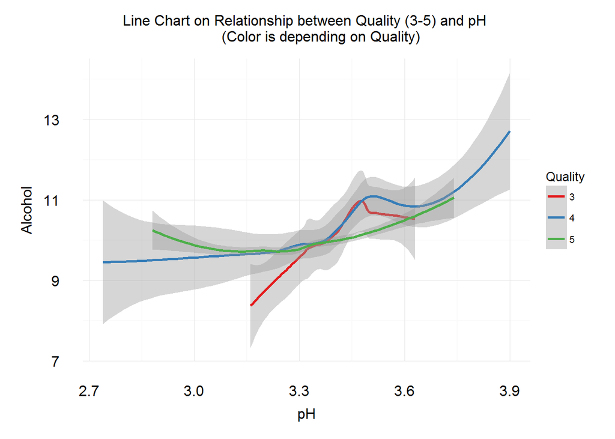

```
##
##  Pearson's product-moment correlation
##
## data:  alcohol and pH
## t = 8.1135, df = 742, p-value = 2.038e-15
## alternative hypothesis: true correlation is not equal to 0
## 95 percent confidence interval:
##  0.2180583 0.3501536
## sample estimates:
##       cor
## 0.2854611
```

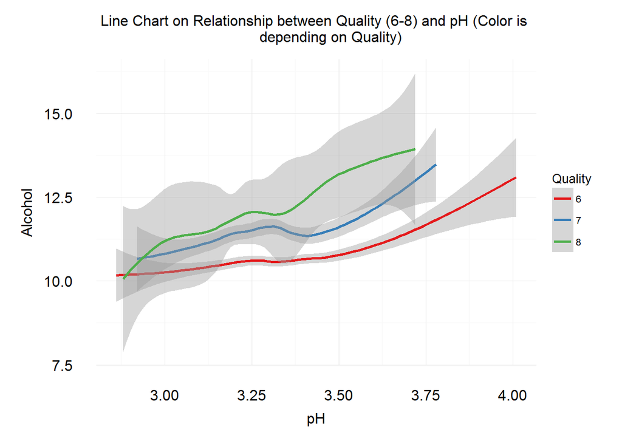

```
##
##  Pearson's product-moment correlation
##
## data:  alcohol and pH
## t = 6.0534, df = 853, p-value = 2.123e-09
## alternative hypothesis: true correlation is not equal to 0
## 95 percent confidence interval:
##  0.1377788 0.2663725
## sample estimates:
##       cor
## 0.2029505
```

# Multivariate Analysis

### Talk about some of the relationships you observed in this part of the investigation. Were there features that strengthened each other in terms of looking at your feature(s) of interest?

Further, we were again able to see the already discussed correlations and their impact to *Quality* of wines.

### OPTIONAL: Did you create any models with your dataset? Discuss the strengths and limitations of your model.

I tried to create a linear model to predict the *Quality* of the wine based on some features like *Alcohol*, *Volatile Acidity*, *Citric Acidity*, *Sulphates* and *Total Sulfur Dioxide*.

The preditions provide a pedicted value (fit) as well as upper (upr) and lower (lwr) value considering a confidence intervall which is choosen at 95 %.

Input data for the test of the first model:

- alcohol = 13.40
- volatile.acidity = 0.62
- citric.acid = 0.67
- sulphates=0.69
- total.sulfur.dioxide=19.00

Result:

```r
modelEstimate
```

```
##        fit      lwr      upr
## 1 6.469428 5.176963 7.761893
```

In fact, the result of the prediction does not fit hte *Quality* which can be seen in the provided data. A specific wine has been picked to test the model and it’s *Quality* was 8, where the prediction showed a value of 6.5.

More tests are necessary to see how much the model fits to predict the quality.

Input data for the first test of the second model:

- alcohol = 13.4
- volatile.acidity = 0.62

Result:

```r
modelEstimate
```

```
##        fit      lwr      upr
## 1 6.442705 5.128702 7.756707
```

Input data for the second test of the second model:

- alcohol = 10.50
- volatile.acidity = 0.5

Result:

```
##        fit      lwr      upr
## 1 5.698685 4.388362 7.009007
```

As well as the first model, the second model requires more tests to see the quality of the predictions.

# Final Plots and Summary

### Plot One

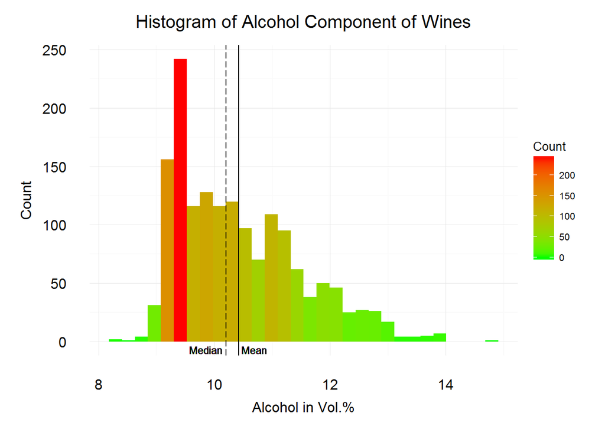

### Description One

Number of Wines with lower 9 Vol.% *Alcohol*:

```
## [1] 7
```

Number of Wines with lower than 10 and more than 9 Vol.% *Alcohol*:

```
## [1] 673
```

Number of Wines with lower than 11 and more than 10 Vol.% *Alcohol*:

```
## [1] 452
```

```
## [1] 305
```

Number of Wines with lower than 13 and more than 12 Vol.% *Alcohol*:

```
## [1] 133
```

Number of Wines with lower than 14 and more than 13 Vol.% *Alcohol*:

```
## [1] 21
```

Number of Wines with lower than 15 and more than 14 Vol.% *Alcohol*:

```
## [1] 8
```

### Plot Two

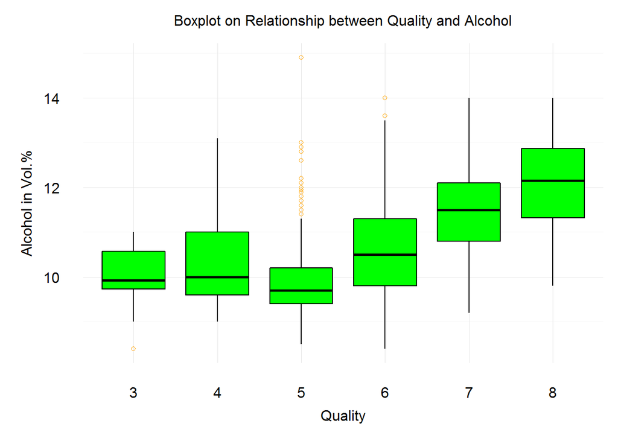

### Description Two

*Alcohol* correlates positvely with the *Quality* of wine. However, *Quality* 5 wines do have a wide range of *Alcohol* values where we can find the highest values of the complete dataset as well as some very low numberes. Even *Quality* 6 ranges are wide in terms of *Alcohol* range. One could assume that mid-quality wines do have a greater range of that feature. At the end this fact might make it more difficult for the linear model to provide precise predictions.

### Plot Three

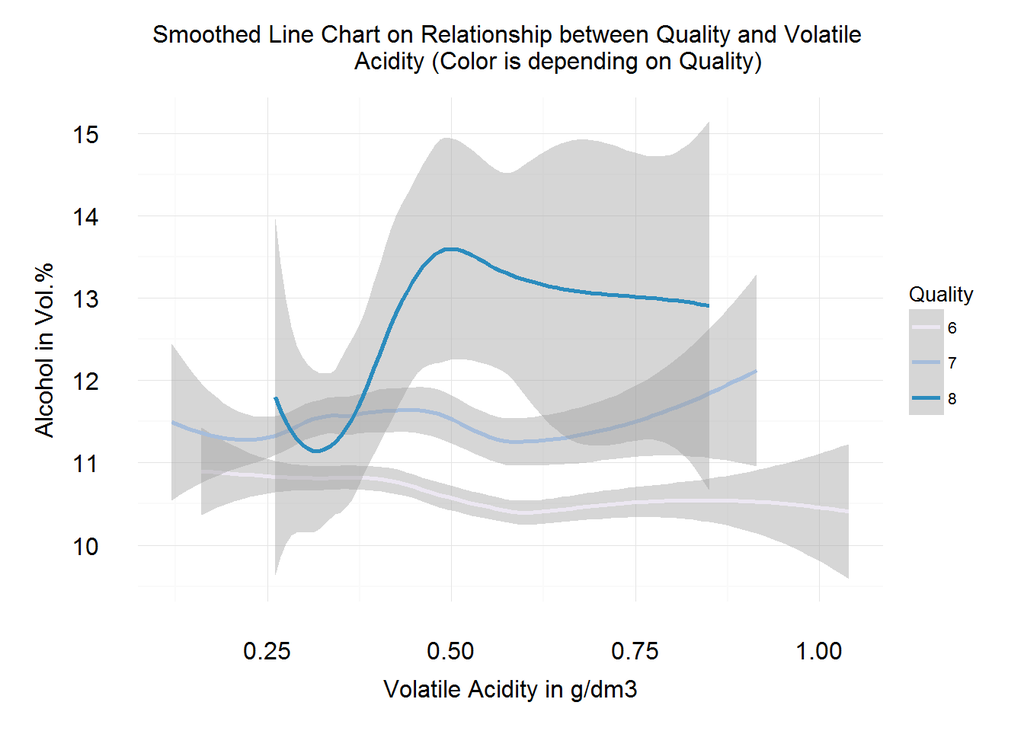

### Description Three

The graph shows smaller ranges of *Volatile Acidity* for higher *Quality*. The below calculated ranges provide detailled information:

Range Quality 8:

```
## [1] 0.59
```

Range Quality 7:

```
## [1] 0.795
```

Range Quality 6:

```
## [1] 0.88
```

*Quality* 8 wines with more than 0.50 g/dm3 *Volatile Acidity* tend to have more *Alcohol* inside than those wines with less than 0.50 g/dm3 *Volatile Acidity*.

Further, as expected, the *Alcohol* values correlate positively with the *Quality* of wines. Comparing the 3 different *Quality* lines in the chart confirms that. However, it is also interesting to see that the variance of *Alcohol* in the wines are small for *Quality* 6 and 7 than for 8.

# Reflection

The red wine dataset contains 1599 different wines and 12 variables. 11 of those variables describe certain components of a wine and how much of a specific component is inside a wine. 1 variable *quality* is describing the quality of the wine rated by a group of experts.

During the observation of the data my focus was mainly on *alcohol* and *pH* value of wine as I thought those are most intersting for my investigations. However, for *alcohol* that showed to be true and in fact there is a quite strong correlation between *alcohol* and *quality* of a wine. Furhter, even more variable correlated with *quality* of wine. For example *volatile acitiy*, *citric acid* and *sulphates*.

With help of the knowledge I gathered during my investigations of the dataset, I constructed two linear models to predict the *Quality* of a wine based on its components. Certainly, the those models are an interesting field for futures research. One things is, to do automated testing on a larger scale on the proposed models to be able to proof the quality of predictions on the complete dataset. Further, as the tests of the model indicated there still seems to be some work to be done, to generate better predictions. Potentially, even other features - not considered in the proposed model - can be included to gain better results.

Clearly the limitations of the investigations are the number of wines which are available in the data set as well as the *quality* variable itself. Although an approach has been taken to make the subjective *quality* of a wine more an *objective* fact by comining *quality* rates from different experts, at the end that is still not reflecting an objective, measureable value.